# DMEL para pronóstico horario de caudal

Reconocimiento modal (CEEMDAN + sample entropy) y ensamble dual Informer–LSTM · Laboratorio 2

## 1. Problema y datos

Se pronostica el **caudal de las próximas 48 horas** de una cuenca a partir de las **336 horas previas** (14 días) de 12 variables: el caudal observado y 11 variables meteorológicas. El caudal está expresado en mm/h (normalizado por el área de la cuenca) y las predicciones se entregan en la misma unidad.

| Partición | Ventanas | Uso |
| --- | --- | --- |
| train (`split = 0`) | 254 000 | entrenamiento, normalización y agrupación MRS |
| validación (`split = 1`) | 18 142 | selección de la mejor época |
| test | 27 983 | predicciones finales; `test_targets.csv` solo se usa en este reporte |

- **508 cuencas** anónimas, todas presentes en las tres particiones: la división es temporal, dentro de cada cuenca.
- Las ventanas de train se solapan mucho entre sí; las de validación y test casi no se solapan con train.
- No hay fechas: no se puede construir el embedding temporal del Informer.
- El caudal es muy asimétrico: mediana de 0.02 mm/h y máximos de ~15 mm/h. La desviación estándar por cuenca va de ~0.001 a 0.55 mm/h (tres órdenes de magnitud) y ~2 % de las ventanas no tiene caudal.

**Referencia ingenua (persistencia).** Repetir el último caudal observado da, en validación, un NSE mediano por cuenca de 0.998 a 1 h, 0.957 a 6 h, 0.841 a 12 h, 0.581 a 24 h y 0.223 a 48 h: el reto está en los horizontes largos.

## 2. El método del paper: DMEL

Wang et al. (2026) proponen **DMEL** (*Dual-Modal Ensemble Learning*) para pronóstico diario de caudal en varios pasos. Tiene dos componentes: una estrategia de reconocimiento modal (MRS) y un ensamble dual.

### 2.1 CEEMDAN

La serie se descompone en modos intrínsecos (IMF) con CEEMDAN mejorado (Colominas et al., 2014). Sea $E_k(\cdot)$ el operador que devuelve el $k$-ésimo modo EMD y $M(\cdot)$ la media local (la señal menos su primer IMF). Con $I$ realizaciones de ruido blanco $w^{(i)}$:

$$r_1=\big\langle M\big(x+\beta_0E_1(w^{(i)})\big)\big\rangle_i,\qquad \mathrm{IMF}_1=x-r_1,$$

$$r_k=\big\langle M\big(r_{k-1}+\beta_{k-1}E_k(w^{(i)})\big)\big\rangle_i,\qquad \mathrm{IMF}_k=r_{k-1}-r_k,$$

con $\beta_0=\varepsilon\,\sigma(x)/\sigma(E_1(w^{(i)}))$ y $\beta_k=\varepsilon\,\sigma(r_k)$. La señal se recupera exactamente: $x=\sum_k \mathrm{IMF}_k+r_K$. El paper usa $\varepsilon=0.2$ e $I=100$.

### 2.2 Sample entropy

La complejidad de cada componente se mide con *sample entropy* (Richman y Moorman, 2000):

$$\mathrm{SampEn}(m,r,L)=-\ln\frac{A}{B},$$

donde $B$ y $A$ cuentan los pares de plantillas de longitud $m$ y $m+1$ cuya distancia de Chebyshev es menor que $r$ (sin contar cada plantilla consigo misma). El paper usa $m=2$ y $r=0.2\,\sigma$.

### 2.3 Estrategia de reconocimiento modal (MRS)

1. Descomponer la serie con CEEMDAN.
2. Calcular la SE de cada IMF y de la serie original.
3. Reagrupar (sumar) los IMF de entropía parecida en componentes reconstruidos (RIMF).
4. Clasificar cada RIMF: **alta frecuencia (HF)** si su SE supera la de la serie original, **baja frecuencia (LF)** si no.

En el paper la agrupación es visual. Por ejemplo, en Shuangpai IMF1…IMF5 quedan como RIMF individuales de alta frecuencia e IMF6+IMF7+IMF8+IMF9 forman el único RIMF de baja frecuencia.

### 2.4 Ensamble dual

Cada tipo de componente va al modelo que mejor lo aprovecha y la predicción es la suma (Ec. 14):

$$\hat{y}(t)=\hat{y}_{\mathrm{Informer}}\big(\mathrm{RIMF}_{\mathrm{HF}}(t)\big)+\hat{y}_{\mathrm{LSTM}}\big(\mathrm{RIMF}_{\mathrm{LF}}(t)\big).$$

- **Informer** (Zhou et al., 2021) para lo irregular y de alta frecuencia: atención ProbSparse, distilling entre capas y decoder generativo que emite todo el horizonte en una pasada.
- **LSTM** para las tendencias suaves de baja frecuencia.
- En la versión multivariable (Sec. 5.6), las covariables se concatenan a las entradas de ambas ramas.

El paper compara contra Informer, Transformer, LSTM, RNN, TimesNet y PatchTST, y hace dos ablaciones: MRS frente a CEEMDAN sin reagrupar (Sec. 5.1) y la asignación invertida LSTM→HF, Informer→LF (Sec. 5.2).

## 3. Adaptación al dataset

### 3.1 Descomposición por ventana: sin información del futuro

El paper descompone **la serie completa** y después la divide en train/validación/test. Como EMD no es causal (las envolventes son splines que pasan por los extremos a ambos lados de *t*), el valor de cada componente en *t* depende de lo que ocurre después: el modelo recibe una pista de los días que debe pronosticar. Aquí cada ventana se descompone **solo con sus 336 h de historia**, igual que en test, donde no existe el futuro.

```
flowchart TD
    A["Serie completa 2002–2005<br/>train + validación + test"] --> B["CEEMDAN de toda la serie"]
    B --> C["Recién aquí se divide 7 : 1.5 : 1.5"]
    C --> D["El modelo recibe IMF(t),<br/>calculado con q(t+1 … T)"]
```

Paper: se descompone y después se divide.

```
flowchart TD
    A["Cada ventana:<br/>solo sus 336 h pasadas"] --> B["CEEMDAN de la ventana"]
    B --> C["IMF(t) usa solo q(… t)"]
    C --> D["Igual en train y en test"]
```

Este trabajo: cada ventana se descompone por separado.

Es el error clásico de los modelos de “descomposición + ensamble” (Fang et al., 2019; Quilty y Adamowski, 2018). Para medirlo, cada ventana de validación se descompone de dos formas: solo con su historia, como en este trabajo, y con su historia más las 48 h futuras, como haría el protocolo del paper.

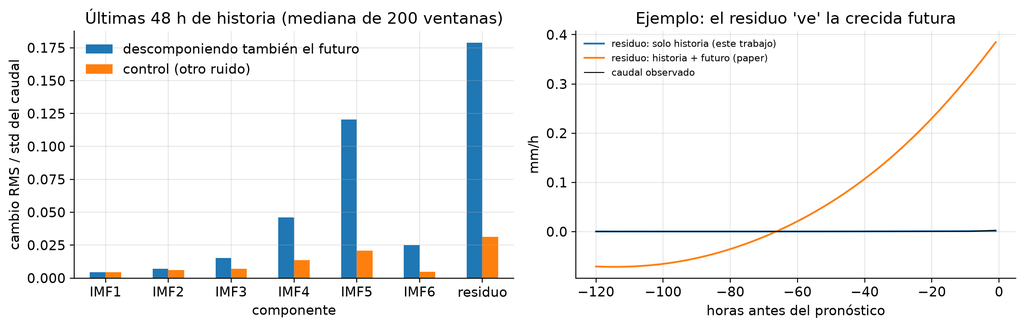

Cambio de los componentes en las últimas 48 h de historia cuando también se descompone el futuro (protocolo del paper), comparado con cambiar solo el ruido de CEEMDAN.

| componente | descomponiendo también el futuro | control (otro ruido) |
| --- | --- | --- |
| IMF1 | 0.00453 | 0.00429 |
| IMF2 | 0.00707 | 0.00608 |
| IMF3 | 0.015 | 0.00703 |
| IMF4 | 0.046 | 0.014 |
| IMF5 | 0.120 | 0.021 |
| IMF6 | 0.025 | 0.00464 |
| residuo | 0.179 | 0.031 |

Los componentes rápidos casi no cambian (IMF1: 0.005 contra 0.004 del control). Los lentos, que van al LSTM, cambian 4–6 veces más que el control: el residuo 0.179 contra 0.031 e IMF5 0.120 contra 0.021 desviaciones del caudal. En el ejemplo de la derecha, el residuo calculado con el futuro sube a 0.38 mm/h antes de la crecida, mientras el caudal observado sigue en ~0: el componente “sabe” lo que viene. Es la fuga de información que la descomposición por ventana evita, y también un motivo para esperar ganancias menores que las del paper.

### 3.2 CEEMDAN y sample entropy implementados desde cero

- `src/dmel/ceemdan.py` implementa el CEEMDAN mejorado en **numba**: sifting con 10 iteraciones fijas, spline cúbica natural propia (algoritmo de Thomas) y un **banco fijo de 100 realizaciones de ruido** con sus modos EMD, calculado una vez y reutilizado en todas las ventanas.
- En los bordes, cada envolvente se extiende con la recta de los dos extremos más cercanos. No se refleja la señal: en una rama ascendente el espejo inventaría un pico en $t=336$, la hora más importante.
- Con $K=6$ IMFs + residuo (336 muestras soportan ~5–6 modos), las 300 125 ventanas se descomponen a ~4.6 ms por ventana con 24 CPUs (el job de CEEMDAN + MRS tomó 38 min). La reconstrucción tiene un error máximo de $10^{-6}$ mm/h.
- `src/dmel/mrs.py` implementa sample entropy con plantillas vectorizadas en numpy.

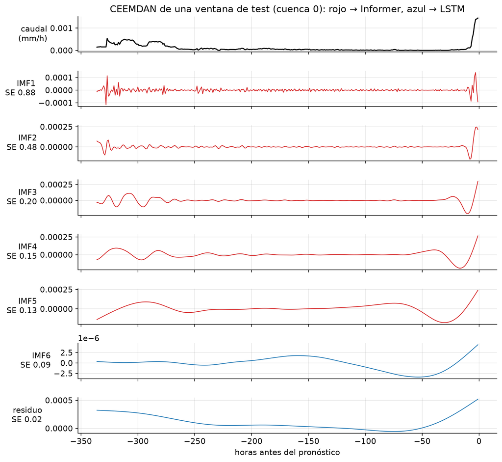

CEEMDAN de una ventana de test. Rojo: RIMF de alta frecuencia (van al Informer); azul: baja frecuencia (van al LSTM).

### 3.3 MRS automático y global

Un solo modelo para 508 cuencas necesita los mismos canales en todas las ventanas, así que la agrupación se decide una vez con 8000 ventanas de train y una regla reproducible:

1. **Voto** de cada componente $k$: fracción de ventanas en que el componente existe y $\mathrm{SE}(c_k)>\mathrm{SE}(q)$. Voto $>0.5$ → RIMF individual de alta frecuencia.
2. El resto se suma por bandas de SE mediana ($\le 0.1$ y $>0.1$), igual que los grupos del paper.
3. Cada suma se re-clasifica con el voto de su propia SE.

Con los valores de la Tabla 2 del paper, esta regla reproduce exactamente la Tabla 3 en sus dos estaciones (`tests/test_mrs.py`).

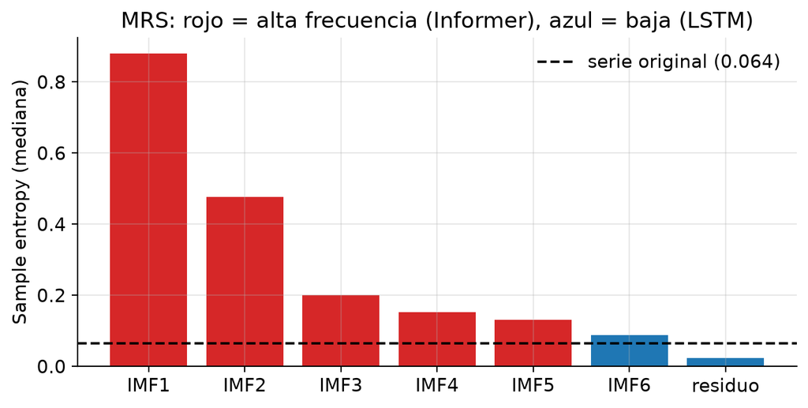

Sample entropy mediana de cada componente y de la serie original.

| componente | presente (%) | SE mediana | voto SE > SE original |
| --- | --- | --- | --- |
| IMF1 | 97.488 | 0.881 | 0.939 |
| IMF2 | 97.475 | 0.476 | 0.864 |
| IMF3 | 97.213 | 0.201 | 0.772 |
| IMF4 | 95.537 | 0.152 | 0.809 |
| IMF5 | 85.325 | 0.132 | 0.651 |
| IMF6 | 44.550 | 0.088 | 0.291 |
| residuo | 97.488 | 0.024 | 0.139 |

| RIMF | componentes | SE mediana | voto | rama |
| --- | --- | --- | --- | --- |
| RIMF1 | IMF1 | 0.881 | 0.939 | alta frecuencia → Informer |
| RIMF2 | IMF2 | 0.476 | 0.864 | alta frecuencia → Informer |
| RIMF3 | IMF3 | 0.201 | 0.772 | alta frecuencia → Informer |
| RIMF4 | IMF4 | 0.152 | 0.809 | alta frecuencia → Informer |
| RIMF5 | IMF5 | 0.132 | 0.651 | alta frecuencia → Informer |
| RIMF6 | IMF6 + residuo | 0.028 | 0.162 | baja frecuencia → LSTM |

El resultado replica el patrón de Shuangpai: cinco RIMF de alta frecuencia (IMF1…IMF5) para el Informer y uno de baja frecuencia (IMF6 + residuo) para el LSTM.

### 3.4 Entradas, escalado y pérdida

Cada rama recibe sus RIMF, las 11 covariables y 2 canales estáticos de la cuenca:

| Entrada | Canales | Contenido | La usan |
| --- | --- | --- | --- |
| `hf` | 18 | 5 RIMF HF + 11 meteorológicas + log $s_b$ + log $\mu_b$ | Informer de DMEL y de la variante; LSTM de la asignación invertida |
| `lf` | 14 | 1 RIMF LF + 11 meteorológicas + 2 estáticos | LSTM de DMEL; Informer de la asignación invertida |
| `lf_q` | 15 | 1 RIMF LF + caudal + 11 meteorológicas + 2 estáticos | LSTM de la variante DMEL + caudal |
| `raw` | 14 | caudal + 11 meteorológicas + 2 estáticos | Ambas ramas de la ablación sin MRS |

- El caudal, los RIMF y el objetivo se dividen por $s_b=\sigma_b+0.01$ mm/h (estadísticas de train de cada cuenca). Escalar conmuta con CEEMDAN porque el ruido es relativo a la desviación de la señal.
- Luego cada canal se estandariza (z-score con estadísticas de train).
- Los canales estáticos devuelven la magnitud del caudal que el escalado por cuenca borra.
- La pérdida es el MSE en el espacio escalado, que equivale a la **NSE*** de Kratzert et al. (2019):

$$\mathcal{L}=\frac{1}{48N}\sum_{n=1}^{N}\sum_{h=1}^{48}\left(\frac{\hat{y}_{n,h}-y_{n,h}}{s_{b(n)}}\right)^2.$$

Sin este escalado, las pocas cuencas de caudal alto dominarían la pérdida.

### 3.5 Arquitectura implementada

```
flowchart LR
    A["Historia · 336 h × 12"] --> Q["Caudal · 336"]
    A --> M["11 covariables + 2 estáticos"]
    Q --> C["CEEMDAN por ventana · 6 IMF + residuo"]
    C --> S["MRS · sample entropy + votos"]
    S --> H["RIMF HF · IMF1…IMF5"]
    S --> L["RIMF LF · IMF6 + residuo"]
    H --> I["Informer · 18 canales"]
    M --> I
    L --> T["LSTM · 14 canales"]
    M --> T
    I --> P["suma"]
    T --> P
    P --> Y["48 h de caudal"]
```

**Informer** (`src/dmel/informer.py`), con los hiperparámetros de la Tabla 1 del paper:

- Embedding: Conv1d ($k=3$, padding *replicate*) + codificación posicional sinusoidal; sin embedding temporal.
- Encoder: 2 capas con **atención ProbSparse** y 1 capa de **distilling** (Conv1d → BatchNorm → ELU → MaxPool, 336 → 168 pasos).
- Decoder generativo de 1 capa: las últimas 48 h conocidas más 48 ceros; self-attention ProbSparse causal, cross-attention completa y proyección a 1 salida por hora.
- $d_{\text{model}}=256$, 8 cabezas, $d_{ff}=1024$, GELU, dropout 0.1.

La atención ProbSparse solo calcula atención completa para las $u=c\ln L$ queries más activas. La actividad de una query se mide con la divergencia KL entre su distribución de atención y una uniforme, que, sin constantes, es

$$M(\mathbf{q}_i,\mathbf{K})=\ln\sum_{j=1}^{L_K}e^{s_{ij}}-\frac{1}{L_K}\sum_{j=1}^{L_K}s_{ij},\qquad
s_{ij}=\frac{\mathbf{q}_i\mathbf{k}_j^\top}{\sqrt{d}}.$$

Calcular el log-sum-exp exige todas las claves. Zhou et al. (2021, Lema 1) demostraron que ese término está acotado por el máximo,

$$\max_j s_{ij}\;\le\;\ln\sum_{j}e^{s_{ij}}\;\le\;\max_j s_{ij}+\ln L_K,$$

así que lo reemplazan por el máximo sobre $U=c\ln L_K$ claves muestreadas:

$$\bar{M}(\mathbf{q}_i,\mathbf{K})=\max_{j\in\mathcal{U}}s_{ij}-\frac{1}{U}\sum_{j\in\mathcal{U}}s_{ij}.$$
Con $c=5$ son 30 de las 336 queries en el encoder y 25 de 96 en el decoder; las demás reciben la media de $V$ (media acumulada si es causal). Respecto del código oficial se corrigieron cuatro detalles: un solo muestreo de claves por pasada (evita un tensor de ~2.6 GB por capa), la media sobre las claves muestreadas, la media acumulada en lugar de la suma y sin el reshape `mix`. Un test verifica que ProbSparse coincide con la atención completa cuando $u\ge L$.

**LSTM** (`src/dmel/models.py`): 2 capas de 256 unidades (Tabla 1); el último estado oculto pasa por Linear(256 → 48).

**Ensamble** (`TwoBranch`): suma de las dos ramas, entrenada de punta a punta sobre el caudal futuro. Los componentes futuros no existen en inferencia, así que no se supervisa cada rama por separado. Total: 3.68 M parámetros.

### 3.6 Diferencias con el paper

| Paper | Este trabajo | Motivo |
| --- | --- | --- |
| CEEMDAN de la serie completa | CEEMDAN de cada ventana (solo historia) | Evitar la fuga de información; en test solo existe la historia |
| Agrupación visual por estación | Regla automática global por votos | 508 cuencas con un modelo; reproduce la Tabla 3 del paper |
| Cada modelo predice componentes futuros | Las ramas se suman y se entrenan sobre el caudal | Los componentes futuros no existen en inferencia |
| Diario: 7 días → 1/3/5/7 días | Horario: 336 h → 48 h directas | Enunciado del laboratorio |
| Embedding temporal global | Omitido | No hay fechas |
| MSE | NSE* con escala por cuenca + 2 canales estáticos | Caudal de magnitudes muy distintas entre cuencas |
| Batch 32, lr 1e-4, 100 épocas | Batch 256, lr 3e-4 + warmup, 100 épocas; se guarda la mejor época de validación | ~250× más datos: una época equivale a ~30 del paper |
| 10 corridas + Wilcoxon | 1 semilla por modelo (en 2 rondas) + Wilcoxon sobre las 508 cuencas | Tiempo de GPU (1 GPU por usuario en KHIPU) |

## 4. Entrenamiento

| Parámetro | Valor |
| --- | --- |
| Optimizador | Adam, lr $3\times10^{-4}$, warmup lineal de 500 pasos |
| Scheduler | ReduceLROnPlateau (factor 0.5, paciencia 2) |
| Batch | 256 (993 pasos por época) |
| Épocas | 100, como el paper; se guarda la época con menor pérdida de validación |
| Regularización | dropout 0.1; clip de norma de gradiente 1.0 |
| Precisión | float32 con TF32 |
| Hardware | NVIDIA RTX A6000 48 GB (KHIPU); ~2 min por época, ~3.3 h por modelo |
| Semillas | 0 (pesos y batches, ruido de CEEMDAN, muestras del MRS y de normalización) |

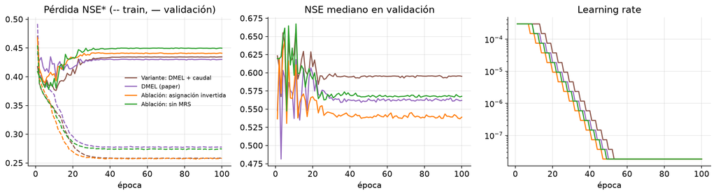

Pérdida NSE* de train y validación, NSE mediano de validación y learning rate durante las 100 épocas.

[output not shown]

### 4.1 ¿Early stopping o 100 épocas?

Hubo dos rondas de entrenamiento. La primera usó early stopping (paciencia 5, máximo 30 épocas). La segunda, que es la que se reporta, entrenó las 100 épocas completas y se quedó con la mejor época de validación. Las métricas de la primera ronda están en `results/earlystop/`.

| Modelo | Ronda 1: épocas / mejor época | NSE mediano test | Ronda 2 (100 épocas): mejor época | NSE mediano test |
| --- | --- | --- | --- | --- |
| DMEL | 16 / 11 | 0.629 | 11 | 0.614 |
| Ablación: asignación invertida | 10 / 5 | 0.629 | 5 | 0.620 |
| Ablación: sin MRS | 10 / 5 | 0.625 | 7 | 0.629 |
| Variante: DMEL + caudal | — (solo en la ronda 2) | — | 11 | 0.624 |

- **La mejor época está siempre entre la 5 y la 11.** Después, la pérdida de train sigue bajando (hasta 0.26–0.28) y la de validación sube (hasta 0.43–0.45): es sobreajuste. Hacia la época 50 el learning rate llega a su piso (~2e-8) y el modelo deja de cambiar.
- **El early stopping no cortó antes de tiempo**: con 100 épocas se eligen las mismas épocas (DMEL y asignación invertida) o casi las mismas (sin MRS: la 7 en vez de la 5). Las 90 épocas extra costaron ~13 h de GPU, contra ~2 h de la primera ronda.
- **Variabilidad entre corridas.** DMEL eligió la misma época 11 con la misma pérdida de validación (0.3988 y 0.3987) y aun así su NSE mediano de test pasó de 0.629 a 0.614. Con la misma semilla, las operaciones no deterministas de la GPU (cuDNN, sumas atómicas) llevan a pesos distintos. Esa variación de ~0.01–0.015 es del mismo orden que las diferencias entre modelos (sección 7.3).

## 5. Modelo base y ablaciones

| Corrida | Rama 1 | Rama 2 | Pregunta |
| --- | --- | --- | --- |
| Persistencia | — | — | Modelo base ingenuo: último caudal observado |
| **DMEL** | Informer(RIMF HF) | LSTM(RIMF LF) | Propuesta del paper |
| Ablación: asignación invertida | LSTM(RIMF HF) | Informer(RIMF LF) | ¿Importa qué modelo recibe cada frecuencia? (paper, Sec. 5.2) |
| Ablación: sin MRS | Informer(caudal) | LSTM(caudal) | ¿Aporta la descomposición? Misma arquitectura y tamaño, sin CEEMDAN ni SE |
| Variante: DMEL + caudal | Informer(RIMF HF) | LSTM(RIMF LF + caudal) | Propia: ¿recupera DMEL las primeras horas si el LSTM también ve el caudal observado? |

Las cuatro redes tienen la misma capacidad (~3.7 M parámetros) y el mismo entrenamiento; solo cambia la entrada de cada rama o la asignación de frecuencias. La variante no es parte del paper: responde al problema de las primeras horas encontrado en la primera ronda.

## 6. Métricas

$$\mathrm{NSE}=1-\frac{\sum_t (q_t-\hat{q}_t)^2}{\sum_t (q_t-\bar{q})^2},\qquad
\mathrm{KGE}=1-\sqrt{(r-1)^2+(\alpha-1)^2+(\beta-1)^2},$$

con $r$ la correlación, $\alpha=\sigma_{\hat{q}}/\sigma_q$ y $\beta=\mu_{\hat{q}}/\mu_q$, y

$$\mathrm{RMSE}=\sqrt{\frac{1}{n}\sum_t (q_t-\hat{q}_t)^2},\qquad \mathrm{MAE}=\frac{1}{n}\sum_t\lvert q_t-\hat{q}_t\rvert
\quad\text{(mm/h)}.$$

- NSE, KGE y RMSE son las tres métricas del paper. NSE vale 1 si el pronóstico es perfecto, 0 si es tan bueno como predecir el caudal promedio y es negativo si es peor. KGE también vale 1 en el óptimo y castiga los hidrogramas aplanados ($\alpha<1$) y el sesgo ($\beta\neq1$).
- NSE y KGE se calculan **por cuenca** (todas sus ventanas y horizontes) y se resume con la **mediana entre cuencas**, para que las 508 pesen igual. RMSE y MAE se agregan sobre todas las predicciones, así que los dominan las cuencas y crecidas grandes.
- NSE por horizonte (1–48 h), como el análisis multi-paso del paper.
- Crecidas: ventanas cuyo pico observado supera el cuantil 0.95 de su cuenca. Error del pico $\mathrm{EP}=(\hat{q}_{\max}-q_{\max})/q_{\max}\times100\,\%$ y desfase del pico en horas (paper, Sec. 5.5).
- Significancia: Wilcoxon pareado sobre el NSE de las cuencas (en lugar de 10 corridas repetidas).

## 7. Resultados

### 7.1 Validación

| métrica | Persistencia | Variante: DMEL + caudal | DMEL (paper) | Ablación: asignación invertida | Ablación: sin MRS |
| --- | --- | --- | --- | --- | --- |
| NSE mediano (por cuenca) | 0.525 | 0.662 | 0.624 | 0.646 | 0.665 |
| KGE mediano (por cuenca) | 0.653 | 0.670 | 0.666 | 0.678 | 0.647 |
| RMSE (mm/h) | 0.138 | 0.101 | 0.102 | 0.102 | 0.101 |
| MAE (mm/h) | 0.024 | 0.023 | 0.023 | 0.023 | 0.024 |
| NSE global | 0.355 | 0.651 | 0.646 | 0.645 | 0.654 |
| Cuencas con NSE < 0 | 75 | 44 | 56 | 38 | 45 |
| EP mediano del pico (%) | -38.630 | -24.987 | -24.937 | -30.961 | -25.672 |
| EP absoluto mediano del pico (%) | 38.794 | 34.501 | 36.777 | 37.428 | 37.122 |
| Desfase absoluto mediano del pico (h) | 18 | 8 | 8 | 9 | 8 |
| NSE a 1 h | 0.998 | 0.978 | 0.944 | 0.957 | 0.978 |
| NSE a 6 h | 0.957 | 0.951 | 0.930 | 0.918 | 0.949 |
| NSE a 12 h | 0.841 | 0.868 | 0.857 | 0.856 | 0.859 |
| NSE a 24 h | 0.581 | 0.663 | 0.642 | 0.668 | 0.669 |
| NSE a 48 h | 0.223 | 0.443 | 0.412 | 0.408 | 0.429 |

### 7.2 Test

| métrica | Persistencia | Variante: DMEL + caudal | DMEL (paper) | Ablación: asignación invertida | Ablación: sin MRS |
| --- | --- | --- | --- | --- | --- |
| NSE mediano (por cuenca) | 0.492 | 0.624 | 0.614 | 0.620 | 0.629 |
| KGE mediano (por cuenca) | 0.626 | 0.693 | 0.655 | 0.672 | 0.641 |
| RMSE (mm/h) | 0.119 | 0.100 | 0.101 | 0.101 | 0.100 |
| MAE (mm/h) | 0.025 | 0.024 | 0.025 | 0.024 | 0.025 |
| NSE global | 0.496 | 0.639 | 0.634 | 0.636 | 0.642 |
| Cuencas con NSE < 0 | 74 | 39 | 37 | 26 | 36 |
| EP mediano del pico (%) | -48.849 | -31.088 | -33.618 | -40.037 | -33.946 |
| EP absoluto mediano del pico (%) | 48.908 | 36.398 | 41.268 | 44.779 | 40.286 |
| Desfase absoluto mediano del pico (h) | 19 | 7 | 8 | 8 | 7.500 |
| NSE a 1 h | 0.998 | 0.984 | 0.943 | 0.958 | 0.984 |
| NSE a 6 h | 0.940 | 0.948 | 0.907 | 0.919 | 0.943 |
| NSE a 12 h | 0.821 | 0.860 | 0.840 | 0.853 | 0.857 |
| NSE a 24 h | 0.538 | 0.672 | 0.649 | 0.660 | 0.656 |
| NSE a 48 h | 0.150 | 0.412 | 0.403 | 0.399 | 0.413 |
| Wilcoxon vs DMEL (paper): p-valor | 1.6e-19 | 2.0e-04 | — | 4.5e-04 | 1.8e-03 |
| Cuencas donde gana DMEL (paper) | 348/508 | 221/508 | — | 224/508 | 231/508 |

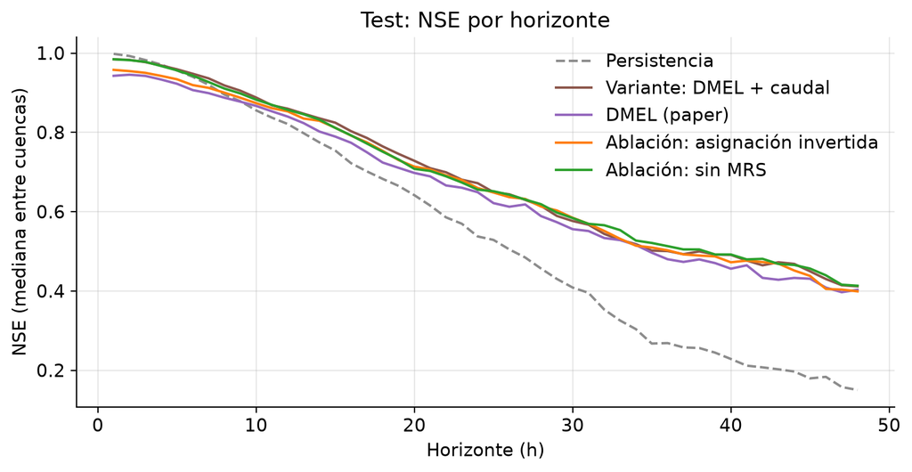

NSE mediano entre cuencas para cada horizonte de pronóstico (test).

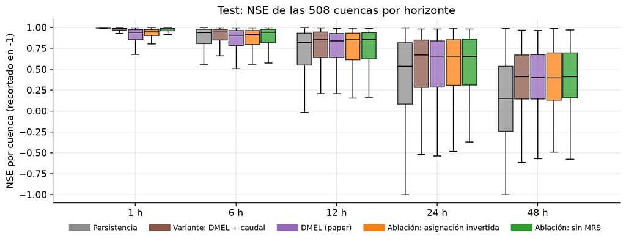

Distribución del NSE de las 508 cuencas en horizontes clave (test).

- **DMEL supera a la persistencia en el agregado**: NSE mediano de 0.614 contra 0.492, KGE de 0.655 contra 0.626 y RMSE de 0.101 contra 0.119 mm/h. Las cuencas con NSE negativo bajan de 74 a 37.
- **La ventaja aparece en los horizontes largos.** Hasta ~6 h la persistencia es mejor (a 1 h, 0.998 contra 0.943 de DMEL): el caudal horario cambia poco y copiar el último valor es difícil de batir. Desde ~7 h las redes la superan y la brecha crece: 0.649 contra 0.538 a 24 h y 0.403 contra 0.150 a 48 h.
- **Las cuatro redes quedan cerca** en el agregado (NSE mediano entre 0.614 y 0.629). La diferencia está en las primeras horas. Los dos modelos que ven el caudal observado (sin MRS y la variante) llegan a 0.984 a 1 h; DMEL (0.943) y la asignación invertida (0.958) solo ven componentes, y justo las últimas horas de cada componente son las menos estables (efecto de borde de la descomposición por ventana).
- **La variante DMEL + caudal es la más equilibrada**: la mejor entre ~6 y ~24 h (0.948 a 6 h, por encima incluso de la persistencia, y 0.672 a 24 h), con el mejor KGE (0.693) y los mejores errores de pico.
- Validación y test cuentan la misma historia (NSE mediano de validación: 0.662 variante, 0.624 DMEL, 0.646 asignación invertida, 0.665 sin MRS, 0.525 persistencia), así que la selección por validación generaliza al periodo de test.

### 7.3 Ablaciones

| comparación | mediana ΔNSE | cuencas donde gana | p-valor |
| --- | --- | --- | --- |
| DMEL (paper) vs Persistencia | 0.081 | 348/508 | 1.6e-19 |
| DMEL (paper) vs Variante: DMEL + caudal | -0.00729 | 221/508 | 2.0e-04 |
| DMEL (paper) vs Ablación: asignación invertida | -0.00549 | 224/508 | 4.5e-04 |
| DMEL (paper) vs Ablación: sin MRS | -0.00551 | 231/508 | 1.8e-03 |

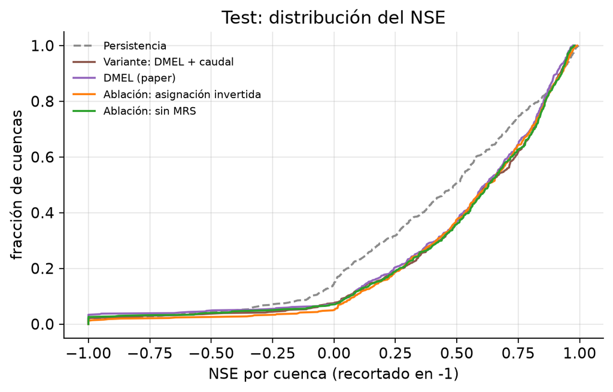

Distribución acumulada del NSE por cuenca (test).

- **DMEL vs persistencia**: mejora el NSE en 348 de 508 cuencas (mediana de +0.081, p = 1.6e-19).
- **Ablación 1, asignación invertida**: es levemente mejor que DMEL (−0.005 en la mediana; DMEL gana en 224 de 508 cuencas, p = 4.5e-04). En la primera ronda eran iguales (p = 0.087). El paper (Sec. 5.2) encontraba una ventaja clara de su asignación; aquí no aparece en ninguna de las dos rondas.
- **Ablación 2, sin MRS**: la misma arquitectura con el caudal crudo también es levemente mejor (−0.006 en la mediana; DMEL gana en 231 de 508 cuencas, p = 1.8e-03). En la primera ronda pasó lo mismo (p = 2.6e-05). Además converge antes (mejor época 7 contra 11).
- **Variante DMEL + caudal**: mejor que DMEL (−0.007; DMEL gana en 221 de 508 cuencas, p = 2.0e-04).

**Cómo leer estas diferencias.** El Wilcoxon es muy significativo porque compara 508 pares de cuencas, pero compara dos modelos entrenados concretos, no dos métodos: no incluye la variabilidad entre corridas. Esa variabilidad es de ~0.01–0.015 en el NSE mediano (sección 4.1), del mismo tamaño que las diferencias entre DMEL y sus ablaciones. La conclusión robusta es de dirección, repetida en las dos rondas: **DMEL nunca supera a sus ablaciones**, así que ni el MRS ni la asignación de frecuencias aportan una mejora medible en este problema. Establecer diferencias de 0.01 exigiría varias semillas por modelo.

La variante confirma dónde está el problema: al devolverle al LSTM el caudal observado, DMEL recupera las primeras horas. Pero su NSE mediano (0.624) queda al nivel del modelo sin MRS (0.629): la ganancia viene del caudal crudo, no de la descomposición.

### 7.4 ¿Qué modelo es mejor?

| Modelo | Qué es | NSE mediano ↑ | KGE ↑ | RMSE (mm/h) ↓ | NSE 1 h ↑ | NSE 48 h ↑ | \|EP\| pico ↓ | Veredicto |
| --- | --- | --- | --- | --- | --- | --- | --- | --- |
| Persistencia | Copiar el último valor | 0.492 | 0.626 | 0.119 | **0.998** | 0.150 | 49 % | Solo gana en 1–6 h |
| **DMEL** | Método del paper | 0.614 | 0.655 | 0.101 | 0.943 | 0.403 | 41 % | La red más débil |
| Asignación invertida | Ablación 1 | 0.620 | 0.672 | 0.101 | 0.958 | 0.399 | 45 % | ≈ DMEL |
| Sin MRS | Ablación 2 | **0.629** | 0.641 | **0.100** | **0.984** | **0.413** | 40 % | Mejor NSE, sin descomponer |
| DMEL + caudal | Variante propia | 0.624 | **0.693** | **0.100** | **0.984** | 0.412 | **36 %** | La más equilibrada |

La variante es el mejor modelo en conjunto: el mejor KGE, el mejor error de pico y el mejor NSE entre 6 y 24 h, y empata en RMSE y a 1 h. Frente a sus ablaciones, DMEL es la red más débil: quitarle el MRS o invertir la asignación no lo empeora. Todas las diferencias entre redes (~0.01) están dentro de la variación entre corridas; la brecha con la persistencia a partir de ~7 h, en cambio, es grande y robusta.

**¿Por qué el MRS no ayuda aquí si en el paper sí?**

1. CEEMDAN es una transformación determinista de la misma historia: no agrega información que la red no pueda extraer del caudal. Además, descomponer por ventana degrada justo las horas más recientes.
2. La descomposición de la serie completa del paper filtra información del futuro. En nuestro estudio de fuga (sección 3.1), los componentes lentos, que son la entrada del LSTM, cambian 4–6 veces más que el control al incluir el futuro (residuo: 0.179 contra 0.031; IMF5: 0.120 contra 0.021). Una parte de la mejora reportada en el paper probablemente viene de ahí.
3. El paper es univariado y usa solo 7 días de entrada, donde la descomposición actúa como ingeniería de variables. Aquí las redes también reciben la lluvia y otras 10 variables meteorológicas.

## 8. Análisis de errores

### 8.1 Crecidas

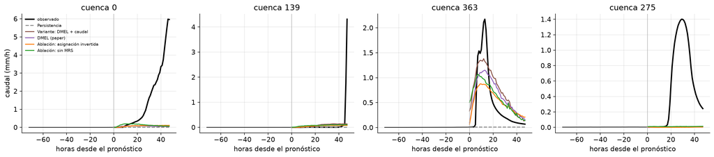

Las mayores crecidas de test: últimas 72 h observadas y 48 h pronosticadas.

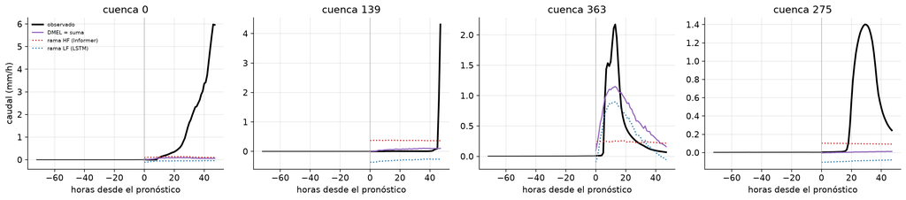

Aporte de cada rama de DMEL en las mismas crecidas.

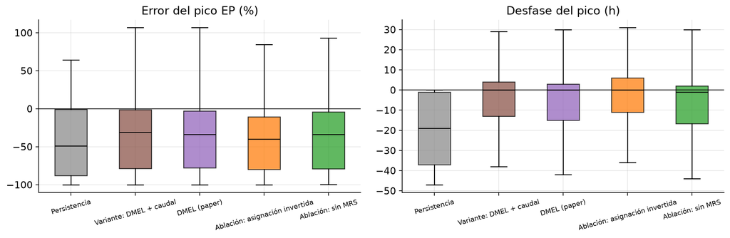

Error de magnitud y desfase del pico en las ventanas de crecida.

### 8.2 Regímenes de caudal y cuencas

| régimen | Persistencia | Variante: DMEL + caudal | DMEL (paper) | Ablación: asignación invertida | Ablación: sin MRS |
| --- | --- | --- | --- | --- | --- |
| bajo | 10.299 | 48.292 | 49.223 | 47.341 | 68.011 |
| medio | 16.011 | 29.525 | 31.444 | 28.678 | 33.675 |
| alto | 39.071 | 31.372 | 32.708 | 31.853 | 31.027 |

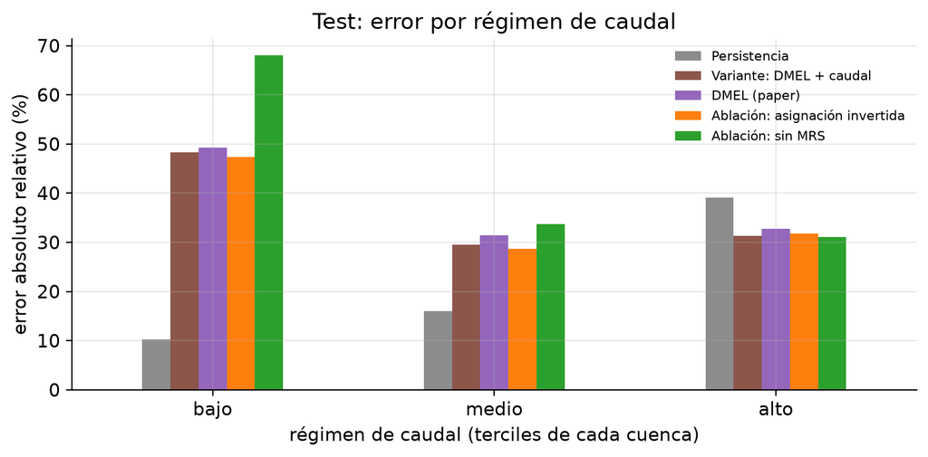

Error absoluto relativo por régimen de caudal (terciles de cada cuenca).

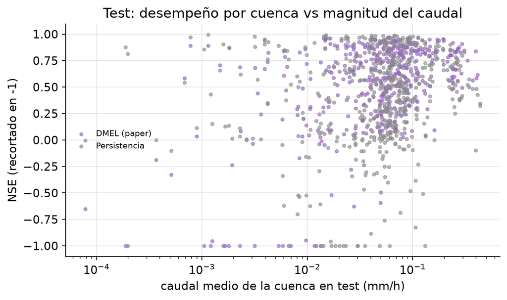

NSE de cada cuenca frente a su caudal medio.

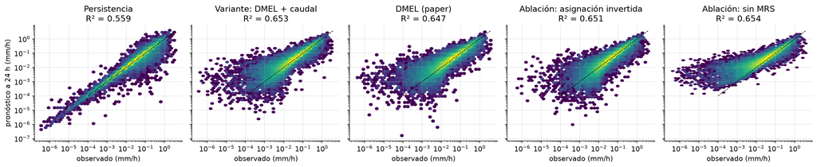

Observado frente a pronosticado a 24 h.

**Principales errores**

- **Crecidas que empiezan después del pronóstico.** Las mayores subidas de test parten de un caudal casi nulo (cuencas 0, 139 y 275) y ningún modelo las anticipa. La lluvia que las provoca todavía no cae en la historia, y las variables meteorológicas futuras (`y_aux`) no están disponibles en inferencia. Cuando la subida ya empezó (cuenca 363), los modelos reaccionan: la variante es la que más se acerca al pico (≈1.4 contra 2.2 mm/h observados), seguida de DMEL (≈1.15), y todos bajan demasiado lento en la recesión.
- **Picos subestimados.** En las ventanas de crecida, todos subestiman el pico: EP mediano de −31 % (variante), −34 % (DMEL y sin MRS), −40 % (asignación invertida) y −49 % (persistencia). El desfase mediano del pico es de 7–8 h para las redes y 19 h para la persistencia.
- **Las ramas no se reparten las frecuencias.** Las dos salidas se compensan con desplazamientos casi constantes (por ejemplo, +0.35 y −0.3 mm/h en la cuenca 139). En la crecida de la cuenca 363 la respuesta la lleva el **LSTM**, que también recibe la lluvia, y no el Informer. Al entrenar sobre la suma, la división en aportes de alta y baja frecuencia no es identificable, así que la interpretación del paper (“el Informer captura los cambios bruscos”) no se sostiene aquí.
- **Caudales bajos.** En el tercio más bajo de cada cuenca, la persistencia tiene un error relativo de 10 %, contra 47–49 % de las redes con MRS y 68 % de la red sin MRS. Las recesiones lentas se predicen casi perfecto copiando el último valor, mientras que las redes agregan ruido relativo cuando la magnitud es mínima (la pérdida NSE* pesa por la variabilidad de la cuenca, no por el nivel del caudal). Es el único régimen donde el MRS sí ayuda: el componente suave de baja frecuencia estabiliza las recesiones. En caudales altos las redes superan a la persistencia (31–33 % contra 39 %).
- **Cuencas casi secas.** Las cuencas con NSE muy negativo se concentran en caudales medios por debajo de 0.01 mm/h. Ahí la varianza del periodo de test es mínima y errores absolutos pequeños dan un NSE muy negativo. Las redes tienen entre 26 y 39 cuencas con NSE negativo, contra 74 de la persistencia.

## 9. Conclusiones

1. Implementamos DMEL desde cero: CEEMDAN mejorado en numba, sample entropy, la regla MRS, el Informer con atención ProbSparse, el LSTM y el ensamble dual. Lo adaptamos a pronóstico horario multi-cuenca sin información del futuro.
2. DMEL supera claramente a la persistencia a partir de ~7 h (NSE mediano de 0.40 contra 0.15 a 48 h; mejor en 348 de 508 cuencas), pero no en las primeras horas.
3. Sin la fuga de información, **ninguno de los dos componentes centrales aporta**: en las dos rondas de entrenamiento, invertir la asignación de frecuencias y quitar el MRS dan resultados iguales o levemente mejores que DMEL. Las diferencias (≤ 0.015 de NSE mediano) son del orden de la variabilidad entre corridas.
4. La descomposición de la serie completa del paper hace que los componentes lentos cambien 4–6 veces más que el ruido propio de CEEMDAN al incluir el futuro. Es una explicación probable de parte de las ganancias reportadas.
5. La variante propia, DMEL con el caudal observado en el LSTM, recupera las primeras horas (0.943 → 0.984 a 1 h) y logra el mejor KGE (0.693), los mejores errores de pico y el mejor NSE entre 6 y 24 h. La ganancia viene del caudal crudo, no de la descomposición.
6. Entrenar 100 épocas, como el paper, eligió los mismos checkpoints que el early stopping (mejor época entre la 5 y la 11): con este volumen de datos, el resto es sobreajuste.
7. Los errores dominantes son las crecidas provocadas por lluvia futura y la subestimación de los picos (~30–40 %). La mejora natural sería usar precipitación pronosticada, si existiera en operación.

## 10. Limitaciones

- **Efecto de borde**: sin el futuro, los componentes de las últimas horas son los menos estables, y son justo los más importantes para pronosticar.
- **MRS global**: una sola agrupación para las 508 cuencas; en algunas, un componente limítrofe (IMF5/IMF6) podría pertenecer al otro grupo.
- **Ramas no supervisadas por separado**: el aporte de cada rama es una interpretación, no un pronóstico de cada banda de frecuencia.
- **Una semilla** por modelo: la significancia se mide entre cuencas, no entre corridas, y la variación entre dos corridas iguales (~0.01–0.015) es comparable a las diferencias entre modelos.
- **Sin covariables futuras**: la lluvia de las próximas 48 h (`y_aux`) no está disponible en inferencia, lo que limita el pronóstico del inicio de crecidas que aún no empezaron.
- **Caudales bajos**: en las recesiones el error relativo de las redes es mucho mayor que el de la persistencia.
- **Primeras horas**: DMEL no ve el caudal crudo y pierde contra la persistencia hasta ~6 h; la variante lo corrige, pero ya no es exactamente el método del paper.

## 11. Reproducibilidad

```bash
uv sync --frozen && uv run pytest                   # 20 tests
bash hpc/push.sh                                    # sube el commit actual a KHIPU
sbatch hpc/decompose.slurm                          # CEEMDAN + MRS (CPU)
MODELS="dmel dmel_q" sbatch hpc/train.slurm         # 100 épocas, ~6.8 h
MODELS="dmel_swap hybrid_raw" sbatch --dependency=afterany:<id> hpc/train.slurm   # + evaluación
bash hpc/pull.sh && quarto render REPORT.qmd
```

Los hiperparámetros, las semillas y el entorno están detallados en el `README.md`. Las predicciones de test están en `predictions/<corrida>_test.csv` con el formato `Id, q_01…q_48` (mm/h).

## 12. Uso de IA generativa

Este trabajo se desarrolló con asistencia de IA generativa (Claude, de Anthropic) para escribir y revisar código y documentación. El grupo revisó y validó las decisiones de implementación y los resultados.

## Referencias

- Wang, W.-c., Gu, M., Li, Z., Wang, Y.-y., Zhao, Y.-w. (2026). DMEL: A novel dual-modal ensemble learning architecture for multi-step runoff prediction. *Applied Soft Computing*, 192, 114792.
- Colominas, M. A., Schlotthauer, G., Torres, M. E. (2014). Improved complete ensemble EMD: A suitable tool for biomedical signal processing. *Biomedical Signal Processing and Control*, 14, 19–29.
- Zhou, H. et al. (2021). Informer: Beyond efficient transformer for long sequence time-series forecasting. *AAAI*.
- Richman, J. S., Moorman, J. R. (2000). Physiological time-series analysis using approximate entropy and sample entropy. *Am. J. Physiol. Heart Circ. Physiol.*, 278(6).
- Kratzert, F. et al. (2019). Towards learning universal, regional, and local hydrological behaviors via machine learning applied to large-sample datasets. *HESS*, 23, 5089–5110.
- Fang, W. et al. (2019). Examining the applicability of different sampling techniques in the development of decomposition-based streamflow forecasting models. *Journal of Hydrology*, 568, 534–550.
- Quilty, J., Adamowski, J. (2018). Addressing the incorrect usage of wavelet-based hydrological and water resources forecasting models for real-world applications with best practices and a new forecasting framework. *Journal of Hydrology*, 563, 336–353.